# PANDAS

Madison Snyder and Magdiel Miranda

Replicathon 2020

## Instructions:

In this R Markdown document, you and your team will create a fully reproducible analysis with the goal of assessing and interpreting the replicability of two pharmacogenomic experiments. This document should contain all of the text and code of your analyses, which will allow others to run, interpret, and reuse your work.

The questions below will help guide you in your analyses and interpretation of results. You don’t need to answer every question, but for the problems you do complete, make sure that you completely justify your conclusions by explaining your reasoning and including numerical summaries and data visualizations wherever possible. There are four tutorials (also R Markdown documents) that will help you learn new tools to tackle these problems, and the questions are divided into four sections corresponding to the tutorials (though many overlap with more than one tutorial). If questions arise during your analyses that do not fit into these problems, feel free to include those as well.

For each answer, include text by simply typing below the question. Include code in code blocks (include three back ticks at the start and end of each code block):

You may find it helpful to use the version control and code sharing system called GitHub to work together with your team so that all of you can edit the same document and keep track of its changes. Here is a [setup guide](https://github.com/datasciencelabs/2016/blob/master/lectures/git-and-github/setting-up-git.Rmd) and [brief introduction to Git and GitHub](https://github.com/datasciencelabs/2016/blob/master/lectures/git-and-github/version-control.Rmd) from another course. The mentors will be able to help if you run into problems.

## Questions:

### Exploratory analysis of pharmacogenomic data

1. How many cell-lines are contained in the data?

```
## [1] 288
```

2. What drug concentrations were used in each study? 15

```
## [1] 15
```

3. Histograms, appart from telling us how the data is distributed, can also make evident potential problems with the data. Plot a histogram of drug viabilities. Does it look as one would expect from the description of the data?

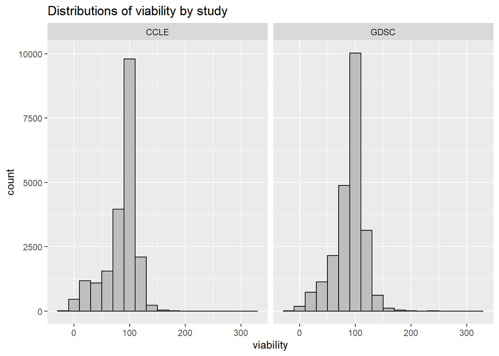

The data looks as though a lot of the trials resulted in 100% viability, meaning the drugs were not effective, while very few trials showed a 0% viability which would be claiming high drug sensitivity.

4. How many viability data points are within the expected range according to the definition of viability (e.g. above 0 and below 100)? Try to come up with explanations about the values that are out of range. Are these due to technical issues? Biology? There are 27626 total trials with expected viability data points between 0 and 100 (percentages).

```
##   min_viability max_viability n_too_small n_too_big
## 1           -20      319.4919          23     15778
```

5. Read the csv file containing the summarized data. What kinds of variables are in the data? What does each column represent?

```
##   cellLine      drug ic50_CCLE  auc_CCLE  ic50_GDSC auc_GDSC
## 1    22RV1 Nilotinib  8.000000 0.0000000 155.269917 0.003935
## 2     5637 Nilotinib  7.475355 0.0072625 219.934550 0.003616
## 3    639-V Nilotinib  8.000000 0.0710125  92.177125 0.007622
## 4      697 Nilotinib  1.910434 0.1573375   3.063552 0.069265
## 5    769-P Nilotinib  8.000000 0.0000000  19.633514 0.028758
## 6    786-0 Nilotinib  8.000000 0.0750125 137.066882 0.005482
```

There is cell line, drug type, and then ic50 and auc for each study. IC50 is the point where 50% of the cells are viable in the cell line being treated.

6. Plot histograms of the viability scores at different levels of drug doses. Are stronger drug concentrations consistent with lower viability scores?

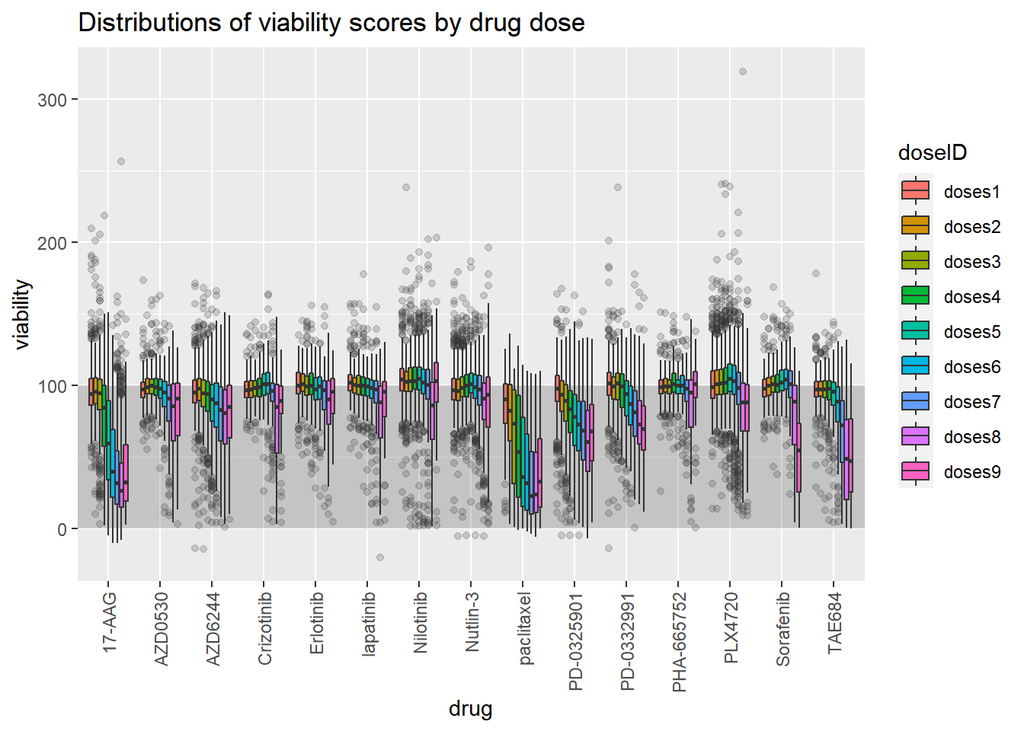

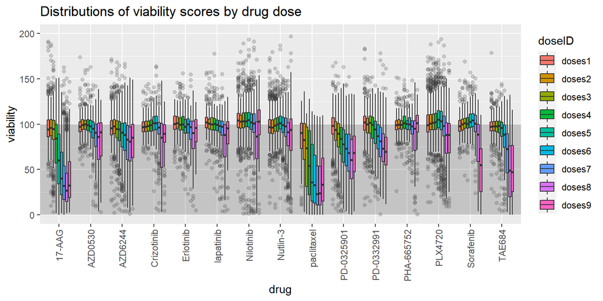

Figure 2: In general, we see lower viability of cells while drug concentration increases. Drugs 17-AAG, poaclitaxel, PD-0325901, and TAE684 impact the most in the viability of cell-lines.

### Using Correlation Measures to Assess Replicability of Drug Response Studies

1. Create a scatterplot for each drug comparing the AUC in GDSC and CCLE for all cell lines (hint: code from Tutorial 1b may help).

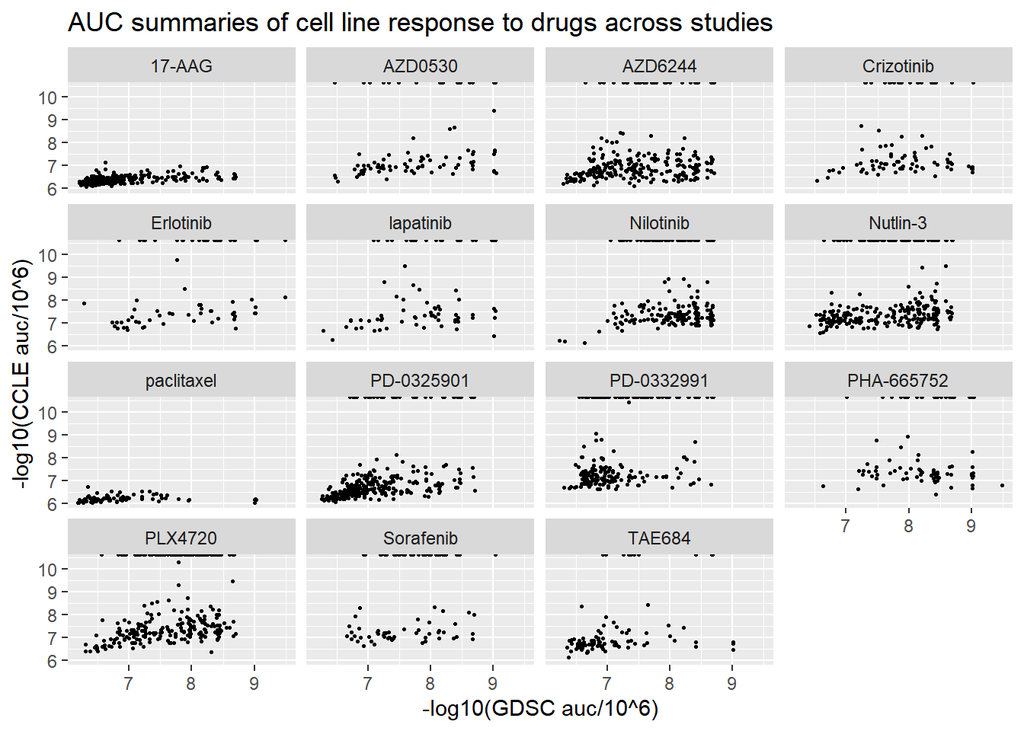

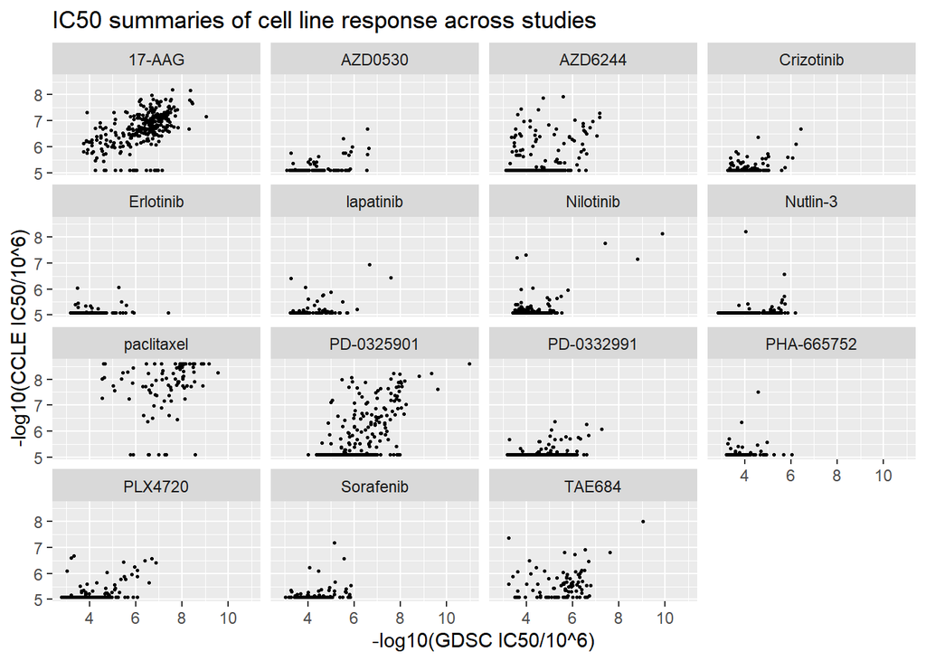

2. Calculate correlation coefficients of the AUC in GDSC and CCLE for each drug (hint: code from Tutorial 1b may help).
3. Based on the scatterplot and correlation values, would you say that they tend to agree? Why or why not?
4. Does the AUC or IC50 suggest more agreement between the studies?
5. Which drug do you think shows the most consistency between the studies? How about the least?
6. If you calculated more than one type of correlation coefficient (for example Pearson and Spearman), how do they differ? Which do you think is a better summary of the consistency between the two studies?

```
## # A tibble: 15 x 3
##    drug       Pearson_ic50 Spearman_ic50
##    <chr>             <dbl>         <dbl>
##  1 17-AAG           0.543         0.586
##  2 AZD0530          0.455         0.360
##  3 AZD6244          0.320         0.244
##  4 Crizotinib       0.409         0.106
##  5 Erlotinib        0.0812        0.0800
##  6 lapatinib        0.427         0.289
##  7 Nilotinib        0.611         0.122
##  8 Nutlin-3         0.143         0.306
##  9 paclitaxel       0.211         0.350
## 10 PD-0325901       0.625         0.580
## 11 PD-0332991       0.240         0.141
## 12 PHA-665752       0.118         0.0554
## 13 PLX4720          0.456         0.358
## 14 Sorafenib        0.277         0.329
## 15 TAE684           0.287         0.268
```

```
## # A tibble: 30 x 3
##    drug       measure      correlation
##    <chr>      <chr>              <dbl>
##  1 17-AAG     Pearson_ic50      0.543
##  2 AZD0530    Pearson_ic50      0.455
##  3 AZD6244    Pearson_ic50      0.320
##  4 Crizotinib Pearson_ic50      0.409
##  5 Erlotinib  Pearson_ic50      0.0812
##  6 lapatinib  Pearson_ic50      0.427
##  7 Nilotinib  Pearson_ic50      0.611
##  8 Nutlin-3   Pearson_ic50      0.143
##  9 paclitaxel Pearson_ic50      0.211
## 10 PD-0325901 Pearson_ic50      0.625
## # ... with 20 more rows
```

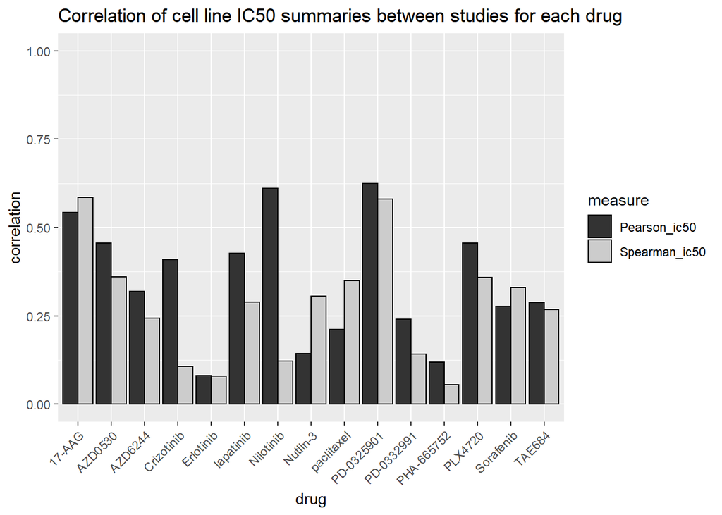

```
## # A tibble: 15 x 3
##    drug       Pearson_auc Spearman_auc
##    <chr>            <dbl>        <dbl>
##  1 17-AAG           0.515      0.569
##  2 AZD0530        NaN          0.444
##  3 AZD6244        NaN          0.290
##  4 Crizotinib     NaN          0.167
##  5 Erlotinib      NaN          0.452
##  6 lapatinib      NaN          0.429
##  7 Nilotinib      NaN          0.147
##  8 Nutlin-3       NaN          0.269
##  9 paclitaxel       0.115      0.384
## 10 PD-0325901     NaN          0.607
## 11 PD-0332991     NaN          0.332
## 12 PHA-665752     NaN         -0.00138
## 13 PLX4720        NaN          0.377
## 14 Sorafenib      NaN          0.289
## 15 TAE684         NaN          0.419
```

```
## # A tibble: 30 x 3
##    drug       measure     correlation
##    <chr>      <chr>             <dbl>
##  1 17-AAG     Pearson_auc       0.515
##  2 AZD0530    Pearson_auc     NaN
##  3 AZD6244    Pearson_auc     NaN
##  4 Crizotinib Pearson_auc     NaN
##  5 Erlotinib  Pearson_auc     NaN
##  6 lapatinib  Pearson_auc     NaN
##  7 Nilotinib  Pearson_auc     NaN
##  8 Nutlin-3   Pearson_auc     NaN
##  9 paclitaxel Pearson_auc       0.115
## 10 PD-0325901 Pearson_auc     NaN
## # ... with 20 more rows
```

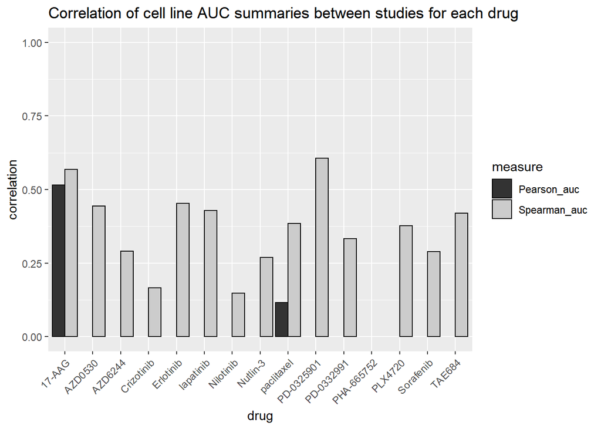

### Identifying biological factors that influence replicability of pharmacogenomic studies

1. Are there any cell lines that seem to be consistently resistant? (Hint: look for the 5 cell lines which seem the most resistant in both studies according to the average drug response by AUC; code from Tutorial 2a may help) What effect might this have on your conclusions and interpretations of the agreement between the studies? For example, do you observe any increase in replicability (as measured by correlation of drug response) if you exclude the most resistant cell lines?
2. Classify each cell line as resistant or sensitive to a drug based on its AUC value (Hint: choose a cutoff for which cell lines with AUC below the cutoff are considered resistant and explain your choice of cutoff(s); code from Tutorial 2a may help). Compare the assigned resistance status of cell lines in GDSC and CCLE for each drug. How often do the two studies agree?
3. Compute the Matthews correlation coefficient for sensitivity status (from #2) of cell lines in GDSC and CCLE for each drug (Hint: code from Tutorial 2a may help). Do certain drugs show more or less agreement between studies?
4. Are there any drugs for which most or all cell lines seem to be resistant in both studies (Hint: code from Tutorial 2a may help)? If so, what are the correlation values for these drugs? What do these results imply about the replicability of these studies?
5. Compare the Matthews correlation coefficient values by drug classes defined in Tutorial 2a (No effect, Narrow effect, Broad effect). Which drug class shows the most agreement between the studies?
6. Would you say that the sensitivity results for the two studies tend to agree?

   **Pearson’s** correlation coefficient: measures the degree of *linear* between variables. **Spearman’s** correlation coefficient: measures the agreement of the *rankings* between variables.

   The most appropiate one is:

   **Matthews’** correlation coefficient: measures the degree of agreement between *categorical* variables.

```
##            CCLE
## GDSC        Resistant Sensitive
##   Resistant      1289       486
##   Sensitive       217       565
```

```
1289 + 565 = 1854
1854 of the drug-cell lines combinations agree for both sensitivity and resistante between the two studies.
```

```
##
##                  Both Resistant GDSC Resistant / CCLE Sensitive
##                            1289                             486
## GDSC Sensitive / CCLE Resistant                  Both Sensitive
##                             217                             565
```

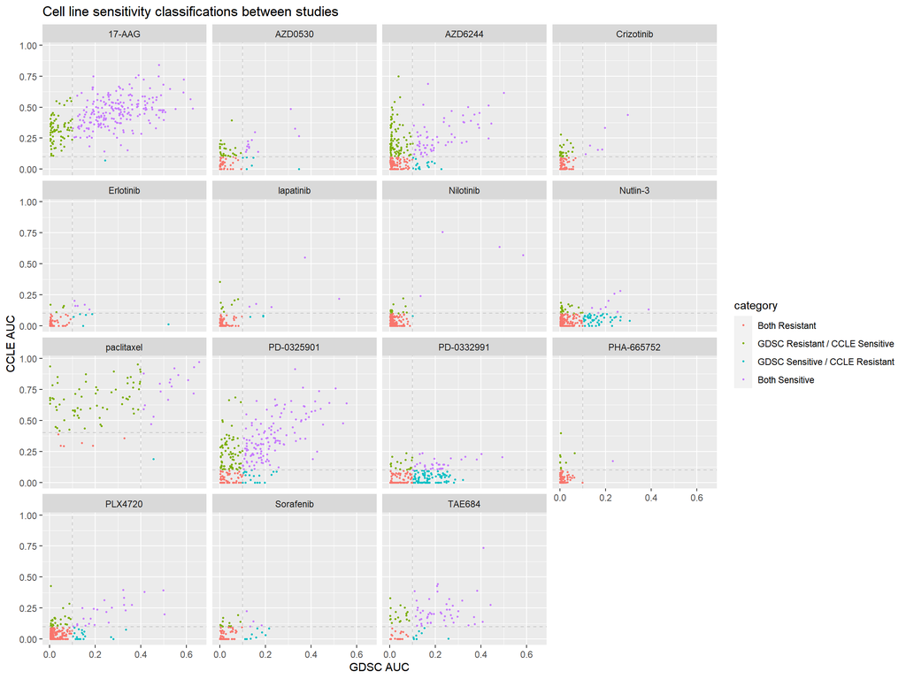

```
## # A tibble: 15 x 2
##    drug       matthews_corr
##    <chr>              <dbl>
##  1 17-AAG           -0.0350
##  2 AZD0530           0.293
##  3 AZD6244           0.297
##  4 Crizotinib        0.371
##  5 Erlotinib         0.432
##  6 lapatinib         0.424
##  7 Nilotinib         0.356
##  8 Nutlin-3          0.0856
##  9 paclitaxel        0.0432
## 10 PD-0325901        0.373
## 11 PD-0332991        0.121
## 12 PHA-665752        0.300
## 13 PLX4720           0.414
## 14 Sorafenib         0.136
## 15 TAE684            0.387
```

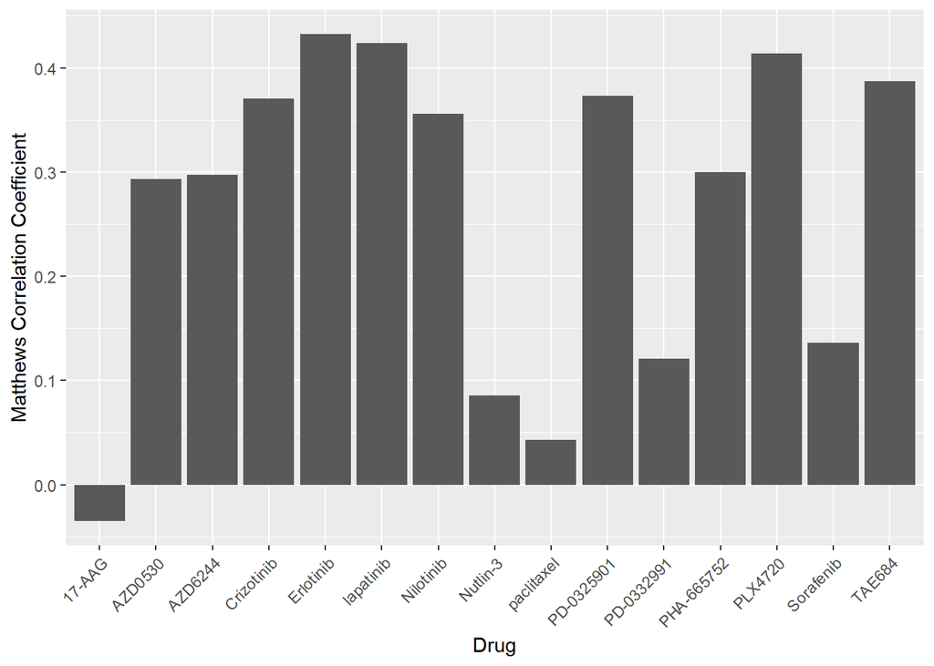

7. For one of the targeted drugs, examine the cell lines that were sensitive in the CCLE and/or GDSC. See if you can find out what types of cells these are by searching the online Cancer Cell Line Encyclopedia http://www.broadinstitute.org/ccle (this will prompt you to register with a username, password, and email address. If you prefer, you can also search the cell line on other websites). See if you can find out what types of cancers this drug is targeted for using the NCI cancer drug database at https://www.cancer.gov/about-cancer/treatment/drugs. Does the list of cell lines found to be sensitive in the two studies agree with this?

### Modeling the relation between two variables (drug concentration vs viability)

1. Explore the response curves for several drug-cell line combinations. How many drugs-cell line combinations contain viability response values that would potentially enable them to be summarized into an IC50 value? You can answer this, for example, by checking whether there are viability values both above and below 50%.
2. Analyze the model-based re-calculations of IC50 and AUCs from the drug 17-AAG in the H4 cell-line and the drug Nilotinib cell-line in the 22RV1 cell-line. See the figure below and asnwer: which statistic is more roboust, IC50 or AUC? Which statistic is more generalizable, IC50 or AUC? Justify your answer with examples and/or using the whole data recalculations from the *modelSummarizedPharmacoData.rds* file.

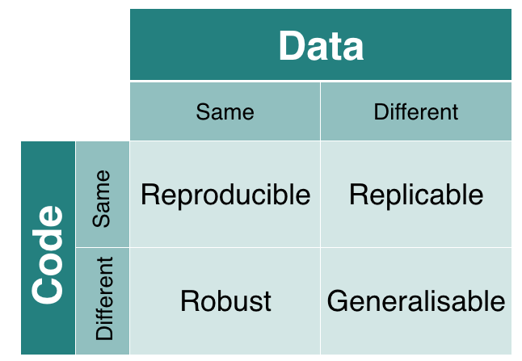

Modified from [Kirstie Whitaker](https://github.com/KirstieJane/).

3. Are the results more replicable if one uses the same code to calculate IC50 or AUC on the different datasets? Hint: you can use code from Tutorial 2a to evaluate this.
4. Summarize the viability curves of all the drugs in each cell-line using the slope of linear model. Is the slope of the linear regression informative of the drug response? Can we improve the replicability of the studies by using the value of the slope instead of IC50s or AUCs?

## Overall Findings:

Summarize your conclusions regarding the level of concordance between the GDSC and CCLE studies. What are the most important considerations for fairly evaluating this question?

Additionally, please prepare a brief (10 minute) presentation of your conclusions and any other aspects of these data sets which you found particularly interesting or challenging.